# Winter_Project

Kupriyanov Semyon

08 02 2022

# Winter project

```r
library(readxl)
df <- read_excel('Data_Cortex_Nuclear.xls')
```

### Step 1. EDA

```r
str(df)
```

```
## tibble [1,080 x 82] (S3: tbl_df/tbl/data.frame)
##  $ MouseID        : chr [1:1080] "309_1" "309_2" "309_3" "309_4" ...
##  $ DYRK1A_N       : num [1:1080] 0.504 0.515 0.509 0.442 0.435 ...
##  $ ITSN1_N        : num [1:1080] 0.747 0.689 0.73 0.617 0.617 ...
##  $ BDNF_N         : num [1:1080] 0.43 0.412 0.418 0.359 0.359 ...
##  $ NR1_N          : num [1:1080] 2.82 2.79 2.69 2.47 2.37 ...
##  $ NR2A_N         : num [1:1080] 5.99 5.69 5.62 4.98 4.72 ...
##  $ pAKT_N         : num [1:1080] 0.219 0.212 0.209 0.223 0.213 ...
##  $ pBRAF_N        : num [1:1080] 0.178 0.173 0.176 0.176 0.174 ...
##  $ pCAMKII_N      : num [1:1080] 2.37 2.29 2.28 2.15 2.13 ...
##  $ pCREB_N        : num [1:1080] 0.232 0.227 0.23 0.207 0.192 ...
##  $ pELK_N         : num [1:1080] 1.75 1.6 1.56 1.6 1.5 ...
##  $ pERK_N         : num [1:1080] 0.688 0.695 0.677 0.583 0.551 ...
##  $ pJNK_N         : num [1:1080] 0.306 0.299 0.291 0.297 0.287 ...
##  $ PKCA_N         : num [1:1080] 0.403 0.386 0.381 0.377 0.364 ...
```

[output cut: 68 more lines]

```r
summary(df)
```

```
##    MouseID             DYRK1A_N         ITSN1_N           BDNF_N
##  Length:1080        Min.   :0.1453   Min.   :0.2454   Min.   :0.1152
##  Class :character   1st Qu.:0.2881   1st Qu.:0.4734   1st Qu.:0.2874
##  Mode  :character   Median :0.3664   Median :0.5658   Median :0.3166
##                     Mean   :0.4258   Mean   :0.6171   Mean   :0.3191
##                     3rd Qu.:0.4877   3rd Qu.:0.6980   3rd Qu.:0.3482
##                     Max.   :2.5164   Max.   :2.6027   Max.   :0.4972
##                     NA's   :3        NA's   :3        NA's   :3
##      NR1_N           NR2A_N          pAKT_N           pBRAF_N
##  Min.   :1.331   Min.   :1.738   Min.   :0.06324   Min.   :0.06404
##  1st Qu.:2.057   1st Qu.:3.156   1st Qu.:0.20575   1st Qu.:0.16459
##  Median :2.297   Median :3.761   Median :0.23118   Median :0.18230
##  Mean   :2.297   Mean   :3.844   Mean   :0.23317   Mean   :0.18185
##  3rd Qu.:2.528   3rd Qu.:4.440   3rd Qu.:0.25726   3rd Qu.:0.19742
##  Max.   :3.758   Max.   :8.483   Max.   :0.53905   Max.   :0.31707
##  NA's   :3       NA's   :3       NA's   :3         NA's   :3
##    pCAMKII_N        pCREB_N           pELK_N          pERK_N
##  Min.   :1.344   Min.   :0.1128   Min.   :0.429   Min.   :0.1492
##  1st Qu.:2.480   1st Qu.:0.1908   1st Qu.:1.204   1st Qu.:0.3374
##  Median :3.327   Median :0.2106   Median :1.356   Median :0.4436
##  Mean   :3.537   Mean   :0.2126   Mean   :1.429   Mean   :0.5459
##  3rd Qu.:4.482   3rd Qu.:0.2346   3rd Qu.:1.561   3rd Qu.:0.6633
##  Max.   :7.464   Max.   :0.3062   Max.   :6.113   Max.   :3.5667
##  NA's   :3       NA's   :3        NA's   :3       NA's   :3
##      pJNK_N            PKCA_N           pMEK_N            pNR1_N
##  Min.   :0.05211   Min.   :0.1914   Min.   :0.05682   Min.   :0.5002
##  1st Qu.:0.28124   1st Qu.:0.2818   1st Qu.:0.24429   1st Qu.:0.7435
##  Median :0.32133   Median :0.3130   Median :0.27739   Median :0.8211
##  Mean   :0.31351   Mean   :0.3179   Mean   :0.27503   Mean   :0.8258
##  3rd Qu.:0.34871   3rd Qu.:0.3523   3rd Qu.:0.30345   3rd Qu.:0.8985
##  Max.   :0.49343   Max.   :0.4740   Max.   :0.45800   Max.   :1.4082
##  NA's   :3         NA's   :3        NA's   :3         NA's   :3
##     pNR2A_N          pNR2B_N          pPKCAB_N          pRSK_N
##  Min.   :0.2813   Min.   :0.3016   Min.   :0.5678   Min.   :0.09594
##  1st Qu.:0.5903   1st Qu.:1.3813   1st Qu.:1.1683   1st Qu.:0.40414
##  Median :0.7196   Median :1.5637   Median :1.3657   Median :0.44060
##  Mean   :0.7269   Mean   :1.5620   Mean   :1.5253   Mean   :0.44285
##  3rd Qu.:0.8486   3rd Qu.:1.7485   3rd Qu.:1.8859   3rd Qu.:0.48210
##  Max.   :1.4128   Max.   :2.7240   Max.   :3.0614   Max.   :0.65096
##  NA's   :3        NA's   :3        NA's   :3        NA's   :3
```

[output cut: 113 more lines]

```
##  Min.   :0.1018   Min.   :0.5865   Length:1080        Length:1080
##  1st Qu.:0.1651   1st Qu.:1.0814   Class :character   Class :character
##  Median :0.1940   Median :1.3174   Mode  :character   Mode  :character
##  Mean   :0.2054   Mean   :1.3378
##  3rd Qu.:0.2352   3rd Qu.:1.5858
##  Max.   :0.4139   Max.   :2.1298
##  NA's   :270
##    Behavior            class
##  Length:1080        Length:1080
##  Class :character   Class :character
##  Mode  :character   Mode  :character
##
##
##
##
```

We see five categorical features and many quantitative features. There are missing values.

Determine the number of mice participating in the experiment.

```r
length(unique(df$MouseID))
```

```
## [1] 1080
```

The quantity does not match the description of the dataframe in the source. Let’s try to find it using the code.

```r
string_names <- sub("_[0-9]+", ".", df$MouseID)
length(unique(string_names))
```

```
## [1] 72
```

There were a total of 72 mice in the experiment.

Let’s see which groups participated in the experiment.

```r
unique(df$class)
```

```
## [1] "c-CS-m" "c-SC-m" "c-CS-s" "c-SC-s" "t-CS-m" "t-SC-m" "t-CS-s" "t-SC-s"
```

There were 8 groups in the experiment.

Let’s look at the balance of groups.

```r
library(dplyr)
```

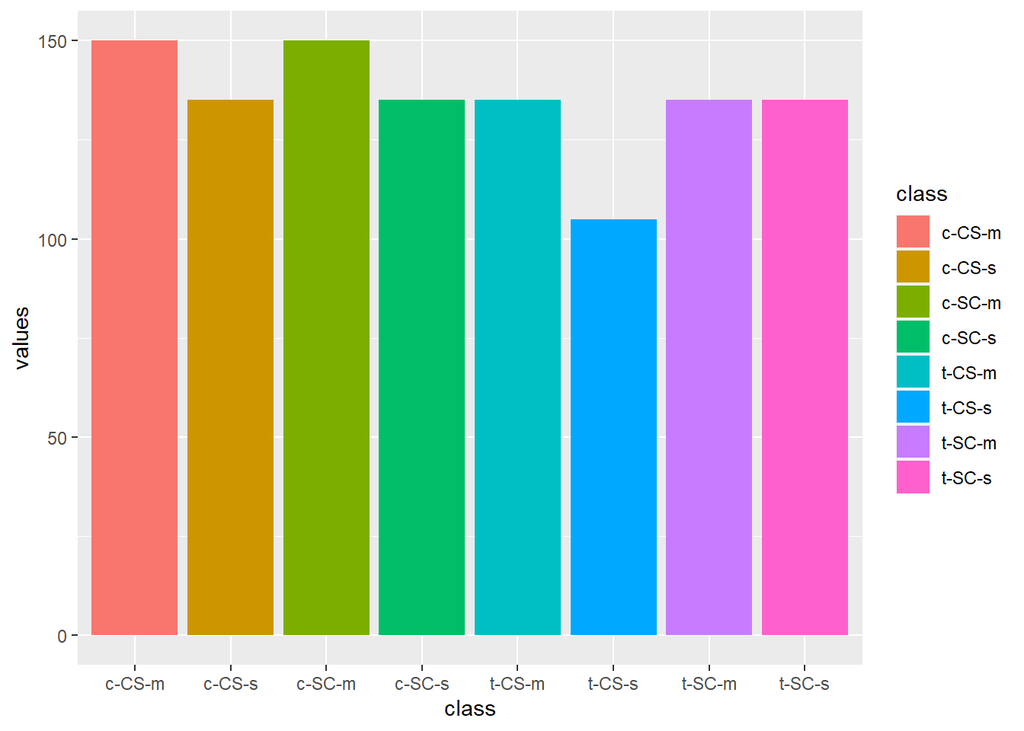

```r
library(ggplot2)
groups <- df %>% group_by(class) %>% summarise(n())
groups$values <- groups$`n()`
groups$`n()` <- NULL
ggplot(groups, aes(x=class, y=values, fill=class))+
  geom_col()
```

The groups are roughly balanced.

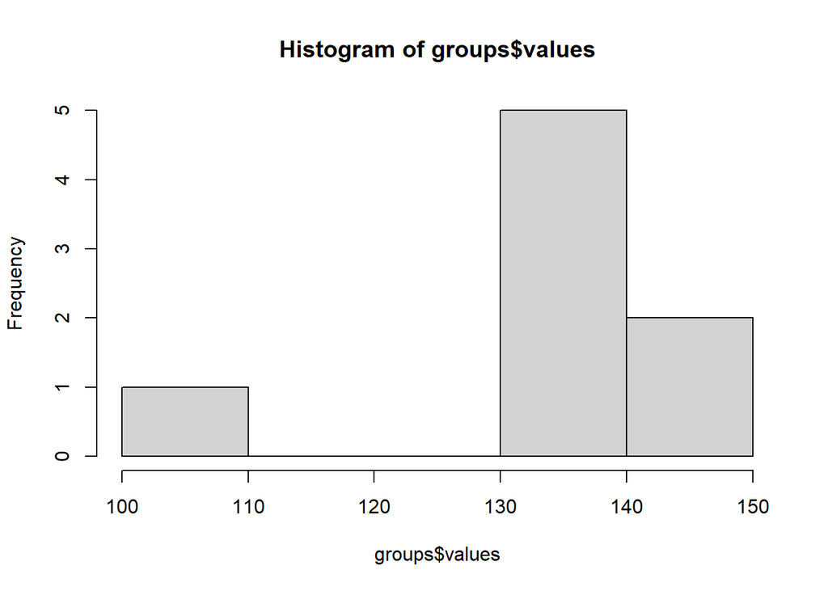

```r
hist(groups$values)
```

There are quite a lot of missing values in the data. Let’s deal with them radically - remove the observations where there is NA.

```r
df_full <- na.omit(df)
```

Let’s look at the balance of groups after the procedure.

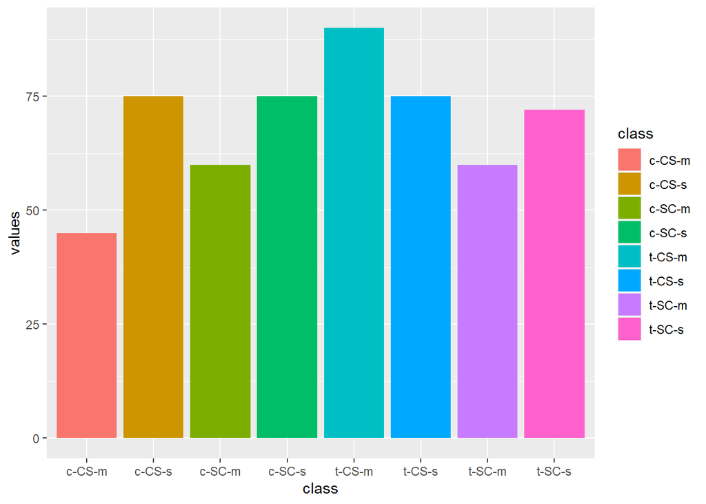

```r
groups2 <- df_full %>% group_by(class) %>% summarise(n())
groups2$values <- groups2$`n()`
groups2$`n()` <- NULL
ggplot(groups2, aes(x=class, y=values, fill=class))+
  geom_col()
```

Now the groups are even more unbalanced, however this seems uncritical and there is no NA.

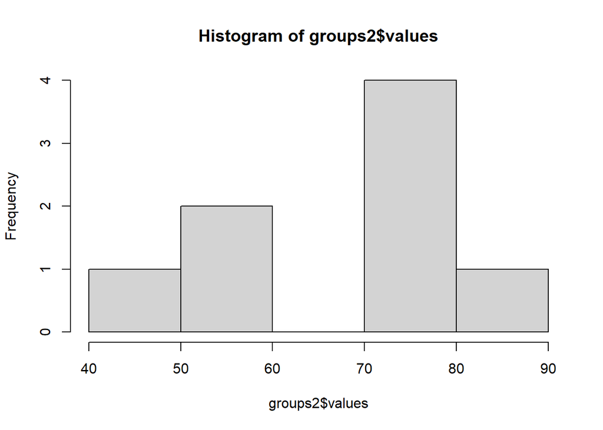

```r
hist(groups2$values)
```

Let’s see how many mice are left after the execution.

```r
string_names2 <- sub("_[0-9]+", ".", df_full$MouseID)
length(unique(string_names2))
```

```
## [1] 37
```

Congratulations, half the mice died for nothing; we just threw out their data in the analysis -_- Statistics are cruel.

(Everything is not so bad, we will try to get around this limitation and the contribution of mice will not be forgotten.)

### Step 2. BDNF_N

We investigate whether there are differences in BDNF_N expression between classes.

*We use untransformed data in this step, with NA. This will increase the power at the expense of the number of observations (na_omit removes all observations from NA, but not all of them will be in BDNF_N).*

*Hooray, mice, your death will not be in vain!*

Let’s visualize the data first.

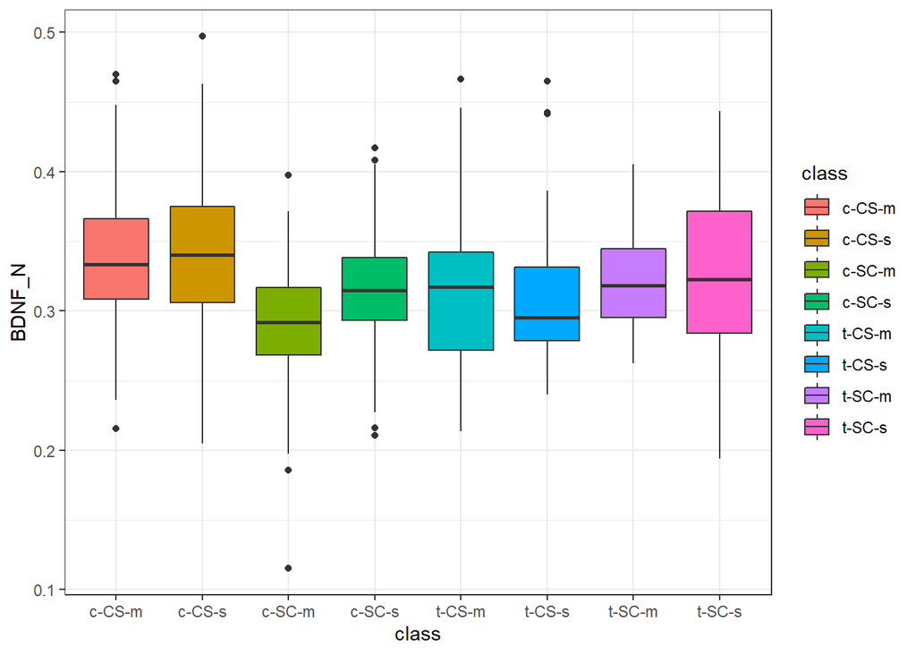

```r
ggplot(df, aes(x=class, y=BDNF_N, fill=class))+
  geom_boxplot()+
  theme_bw()
```

We see outliers, they should be removed (there aren’t many of them, so we’ll just delete them).We also need to check the normality of the distribution and the homogeneity of the variances.

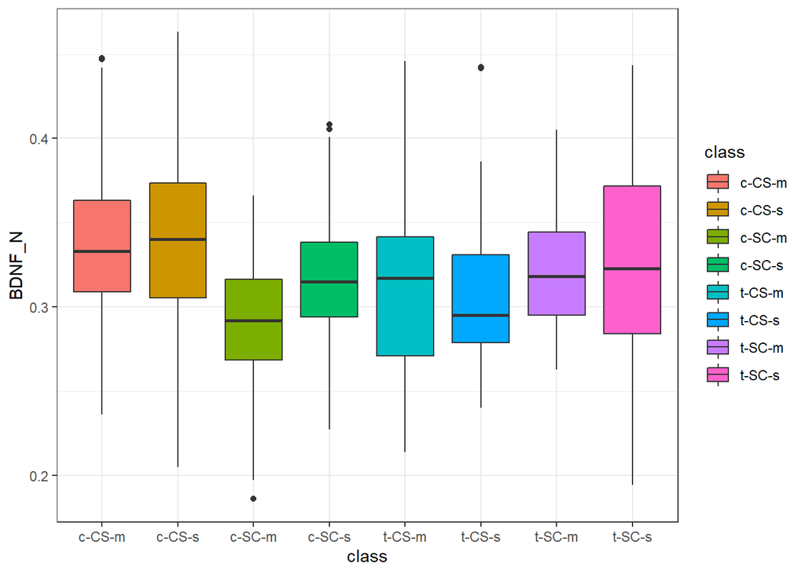

```r
df_BDNF = df

bad_samples = c(df_BDNF[which(df_BDNF$class == "c-CS-m" & (df_BDNF$BDNF_N > 0.45 | df_BDNF$BDNF_N < 0.22)),]$MouseID,
df_BDNF[which(df_BDNF$class == "c-CS-s" & df_BDNF$BDNF_N > 0.47),]$MouseID,
df_BDNF[which(df_BDNF$class == "c-SC-m" & (df_BDNF$BDNF_N > 0.37 | df_BDNF$BDNF_N < 0.18)),]$MouseID,
df_BDNF[which(df_BDNF$class == "c-SC-s" & (df_BDNF$BDNF_N > 0.409 | df_BDNF$BDNF_N < 0.225)),]$MouseID,
df_BDNF[which(df_BDNF$class == "t-CS-m" & df_BDNF$BDNF_N > 0.45),]$MouseID,
df_BDNF[which(df_BDNF$class == "t-CS-s" & df_BDNF$BDNF_N > 0.45),]$MouseID)

df_BDNF = df_BDNF[-which(df_BDNF$MouseID %in% bad_samples), ]

ggplot(df_BDNF, aes(x=class, y=BDNF_N, fill=class))+
  geom_boxplot()+
  theme_bw()
```

Already better, we will correct a little more

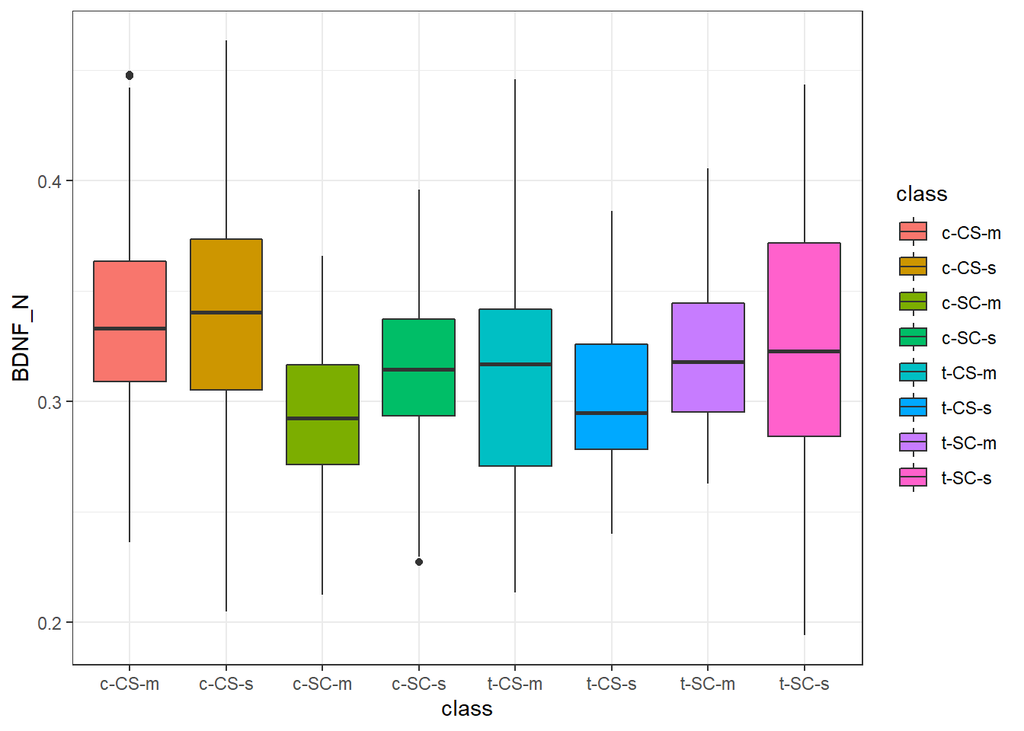

```r
df_BDNF = df

bad_samples = c(df_BDNF[which(df_BDNF$class == "c-CS-m" & (df_BDNF$BDNF_N > 0.45 | df_BDNF$BDNF_N < 0.22)),]$MouseID,
                df_BDNF[which(df_BDNF$class == "c-CS-s" & df_BDNF$BDNF_N > 0.47),]$MouseID,
                df_BDNF[which(df_BDNF$class == "c-SC-m" & (df_BDNF$BDNF_N > 0.37 | df_BDNF$BDNF_N < 0.2)),]$MouseID,
                df_BDNF[which(df_BDNF$class == "c-SC-s" & (df_BDNF$BDNF_N > 0.40 | df_BDNF$BDNF_N < 0.225)),]$MouseID,
                df_BDNF[which(df_BDNF$class == "t-CS-m" & df_BDNF$BDNF_N > 0.45),]$MouseID,
                df_BDNF[which(df_BDNF$class == "t-CS-s" & df_BDNF$BDNF_N > 0.4),]$MouseID)

df_BDNF = df_BDNF[-which(df_BDNF$MouseID %in% bad_samples), ]

ggplot(df_BDNF, aes(x=class, y=BDNF_N, fill=class))+
  geom_boxplot()+
  theme_bw()
```

Fine. Let’s look at class balance

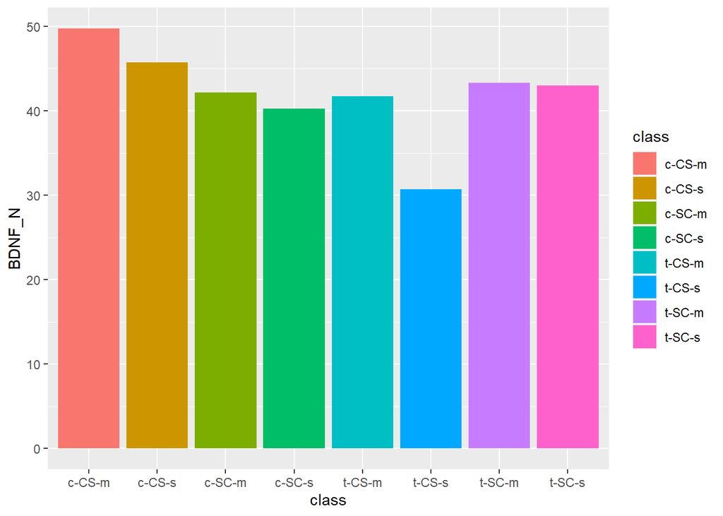

```r
ggplot(df_BDNF, aes(x=class, y=BDNF_N, fill=class))+
  geom_col()
```

More or less uniform classes. Now let’s check if we can use ANOVA at all:

1. Are the groups normally distributed?

```r
df_BDNF %>% group_by(class) %>%
  summarise(p.value = shapiro.test(BDNF_N)$p.value)
```

```
## # A tibble: 8 x 2
##   class  p.value
##   <chr>    <dbl>
## 1 c-CS-m 0.0950
## 2 c-CS-s 0.367
## 3 c-SC-m 0.637
## 4 c-SC-s 0.0527
## 5 t-CS-m 0.0253
## 6 t-CS-s 0.00818
## 7 t-SC-m 0.00463
## 8 t-SC-s 0.184
```

No. So we will use the nonparametric analogue of ANOVA

2. Equality of variances

```r
bartlett.test(BDNF_N~class, data=df_BDNF)
```

```
##
##  Bartlett test of homogeneity of variances
##
## data:  BDNF_N by class
## Bartlett's K-squared = 90.561, df = 7, p-value < 2.2e-16
```

But this is already a problem. Homogeneity of variances is not respected, so we cannot actually use either ANOVA or Kruskal-Wallis test. Could this be due to the removal of outliers?

```r
bartlett.test(BDNF_N~class, data=df)
```

```
##
##  Bartlett test of homogeneity of variances
##
## data:  BDNF_N by class
## Bartlett's K-squared = 60.192, df = 7, p-value = 1.382e-10
```

No, that’s not the point. Let’s try another criterion.

```r
library(car)
leveneTest(BDNF_N~class, data=df_BDNF)
```

```
## Levene's Test for Homogeneity of Variance (center = median)
##         Df F value    Pr(>F)
## group    7  12.354 2.929e-15 ***
##       1049
## ---
## Signif. codes:  0 '***' 0.001 '**' 0.01 '*' 0.05 '.' 0.1 ' ' 1
```

Similar result.

Here, in fact, we could transform the data (although they are already logarithmic, judging by the description). We could also use other techniques such as generalized linear models. But we’ll try something a little different (because I don’t know much about GLMs).Let’s assume that I didn’t do these tests and do an ANOVA

```r
df_BDNF = df_BDNF[-which(is.na(df_BDNF$BDNF_N)),] # remove NA's
aov_model <- aov(BDNF_N~class, df_BDNF)
summary(aov_model)
```

```
##               Df Sum Sq Mean Sq F value Pr(>F)
## class          7 0.2708 0.03868   19.88 <2e-16 ***
## Residuals   1049 2.0415 0.00195
## ---
## Signif. codes:  0 '***' 0.001 '**' 0.01 '*' 0.05 '.' 0.1 ' ' 1
```

ANOVA shows significant differences. Let’s diagnose the model:

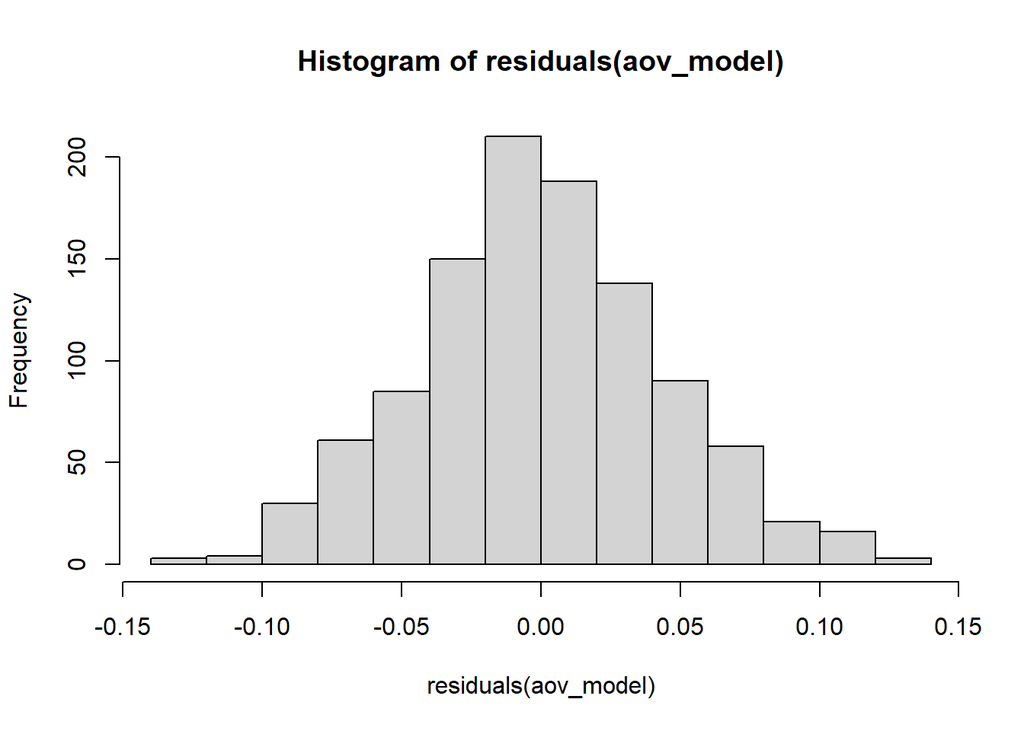

```r
hist(residuals(aov_model))
```

The residuals are normally distributed.

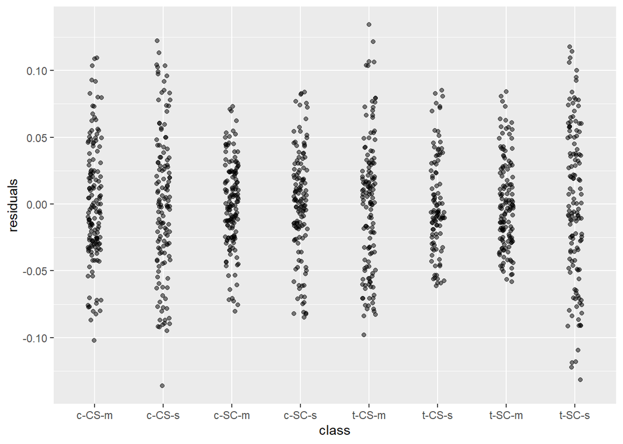

```r
df_BDNF$residuals <- residuals(aov_model)
ggplot(df_BDNF, aes(x = class, y = residuals))+
  geom_jitter(width = 0.1, alpha = 0.5)
```

The variances of residuals by eye also differ little. Yes, and on boxplot, the variances were not super different. In the course on statistics on the Stepik, it was said that with large samples, even minor deviations are recognized as statistically significant and standard tests may show an incorrect result (a simulated sample from a normal distribution with a large N gave a negative result on the Shapiro-Wilk test). Let’s try a non-perimetric analysis.

```r
kruskal.test(BDNF_N~class, data=df_BDNF)
```

```
##
##  Kruskal-Wallis rank sum test
##
## data:  BDNF_N by class
## Kruskal-Wallis chi-squared = 124.79, df = 7, p-value < 2.2e-16
```

The test also showed significant differences. We can’t trust him 100% straight, we’ll check it on pairwise comparisons using Dann’s test with Holm’s correction.

```r
library("rstatix")
df_BDNF %>%
  dunn_test(BDNF_N~class, p.adjust.method = "holm")
```

```
## # A tibble: 28 x 9
##    .y.    group1 group2    n1    n2 statistic        p    p.adj p.adj.signif
##  * <chr>  <chr>  <chr>  <int> <int>     <dbl>    <dbl>    <dbl> <chr>
##  1 BDNF_N c-CS-m c-CS-s   147   134    0.0803 9.36e- 1 1   e+ 0 ns
##  2 BDNF_N c-CS-m c-SC-m   147   144   -8.58   9.23e-18 2.58e-16 ****
##  3 BDNF_N c-CS-m c-SC-s   147   129   -4.38   1.16e- 5 2.32e- 4 ***
##  4 BDNF_N c-CS-m t-CS-m   147   134   -4.66   3.17e- 6 6.98e- 5 ****
##  5 BDNF_N c-CS-m t-CS-s   147   102   -6.48   9.21e-11 2.39e- 9 ****
##  6 BDNF_N c-CS-m t-SC-m   147   135   -3.03   2.47e- 3 3.33e- 2 *
##  7 BDNF_N c-CS-m t-SC-s   147   132   -2.31   2.10e- 2 2.35e- 1 ns
##  8 BDNF_N c-CS-s c-SC-m   134   144   -8.46   2.58e-17 6.96e-16 ****
##  9 BDNF_N c-CS-s c-SC-s   134   129   -4.37   1.26e- 5 2.40e- 4 ***
## 10 BDNF_N c-CS-s t-CS-m   134   134   -4.63   3.59e- 6 7.54e- 5 ****
## # ... with 18 more rows
```

Pairwise comparisons show significant differences. Probably, we will be more inclined to believe that there really are differences, although these data should be treated with caution.

### Step 3. Regression

##### Let’s build all-features model:

1. Data preparation

First, replace the gaps with the average (not the best strategy, but we’ll try)

```r
# replace NAs with group means
df_fill_na <- df[,-c(1,81,80,79)]

for (i in 1:ncol(df_fill_na)-1){
  if(any(is.na(df_fill_na[,i])) == T){
    values_na = which(is.na(df_fill_na[,i]))
    for (j in 1:length(values_na)){
      class_of = df_fill_na$class[values_na[j]]
      df_fill_na[values_na[j],i] = mean(df_fill_na[which(df_fill_na[,ncol(df_fill_na)] == class_of),i][[1]]
                             , na.rm = T)
    }
  }
}

any(is.na(df_fill_na))
```

```
## [1] FALSE
```

Ok, let’s split the data into training and test sets.

```r
y <- df_fill_na$ERBB4_N
x <- df_fill_na[-c(78, which(colnames(df_fill_na) == 'ERBB4_N'))] # remove categorial feachures and target
set.seed(7)
train <- sample(1:nrow(x), nrow(x)*0.75) # ala train/test split

x_train <- as.matrix(x[train, ])
y_train <- y[train]
x_test <- as.matrix(x[-train, ])
y_test <- y[-train]
```

The expression of different proteins is different, so we standardize the data.

```r
x_train_scaled <- scale(x_train)
x_test_scaled <- scale(x_test, center=apply(x_train, 2, mean), scale=apply(x_train, 2, sd))
nwe_data <- data.frame(cbind(x_train_scaled, y_train))
```

2. Model with all predictors

```r
lin_mod <- lm(y_train~., nwe_data)
summary(lin_mod)
```

```
##
## Call:
## lm(formula = y_train ~ ., data = nwe_data)
##
## Residuals:
##       Min        1Q    Median        3Q       Max
## -0.023803 -0.003950 -0.000051  0.003529  0.036210
##
## Coefficients: (1 not defined because of singularities)
##                   Estimate Std. Error t value Pr(>|t|)
## (Intercept)      1.564e-01  2.324e-04 673.079  < 2e-16 ***
## DYRK1A_N        -3.408e-03  1.831e-03  -1.861 0.063085 .
## ITSN1_N          2.197e-03  1.829e-03   1.201 0.230122
## BDNF_N          -6.213e-04  8.398e-04  -0.740 0.459625
## NR1_N           -2.549e-03  1.498e-03  -1.702 0.089159 .
## NR2A_N          -5.199e-04  1.027e-03  -0.506 0.612877
## pAKT_N           1.352e-03  6.765e-04   1.999 0.046011 *
## pBRAF_N         -1.387e-03  7.180e-04  -1.932 0.053767 .
## pCAMKII_N        4.673e-04  6.746e-04   0.693 0.488656
## pCREB_N         -1.670e-03  7.620e-04  -2.191 0.028768 *
## pELK_N          -6.696e-04  6.669e-04  -1.004 0.315674
## pERK_N          -1.025e-03  9.891e-04  -1.036 0.300608
## pJNK_N          -2.449e-03  1.007e-03  -2.433 0.015226 *
## PKCA_N           1.916e-03  9.187e-04   2.085 0.037397 *
## pMEK_N          -2.798e-04  8.881e-04  -0.315 0.752804
## pNR1_N          -2.335e-03  1.228e-03  -1.902 0.057580 .
## pNR2A_N          9.527e-04  9.396e-04   1.014 0.310961
## pNR2B_N          1.240e-03  1.164e-03   1.065 0.287257
## pPKCAB_N         3.882e-05  1.031e-03   0.038 0.969958
## pRSK_N           1.033e-03  6.831e-04   1.512 0.130919
## AKT_N            1.182e-03  8.892e-04   1.329 0.184109
## BRAF_N          -5.262e-04  1.737e-03  -0.303 0.762008
## CAMKII_N         1.229e-03  8.077e-04   1.522 0.128419
## CREB_N          -5.046e-04  6.297e-04  -0.801 0.423254
## ELK_N            1.228e-03  9.941e-04   1.235 0.217150
## ERK_N            2.920e-03  1.220e-03   2.393 0.016946 *
## GSK3B_N          1.752e-03  1.233e-03   1.421 0.155691
## JNK_N            7.124e-04  8.568e-04   0.832 0.405960
## MEK_N            6.894e-04  6.752e-04   1.021 0.307619
## TRKA_N           8.552e-04  1.210e-03   0.707 0.479895
```

[output cut: 38 more lines]

```
## BAD_N           -8.977e-04  4.892e-04  -1.835 0.066876 .
## BCL2_N           6.312e-05  4.222e-04   0.150 0.881195
## pS6_N                   NA         NA      NA       NA
## pCFOS_N         -1.226e-03  4.506e-04  -2.721 0.006654 **
## SYP_N            1.177e-03  5.098e-04   2.308 0.021254 *
## H3AcK18_N        5.155e-04  4.625e-04   1.115 0.265414
## EGR1_N           2.463e-04  4.916e-04   0.501 0.616557
## H3MeK4_N         8.598e-04  5.581e-04   1.541 0.123836
## CaNA_N          -1.828e-03  8.767e-04  -2.085 0.037386 *
## ---
## Signif. codes:  0 '***' 0.001 '**' 0.01 '*' 0.05 '.' 0.1 ' ' 1
##
## Residual standard error: 0.006613 on 734 degrees of freedom
## Multiple R-squared:  0.821,  Adjusted R-squared:  0.8027
## F-statistic: 44.87 on 75 and 734 DF,  p-value: < 2.2e-16
```

Conclusion: a lot of insignificant features, but the coefficient of determination, even corrected, is quite good; the model is statistically significant. Let’s check it with test data.

3. Test evaluation

```r
y_pred <- predict(lin_mod, data.frame(x_test_scaled))
r2 <- 1 - sum((y_test - y_pred)**2)/sum((y_test - mean(y_test))**2)
cat("R-squared: ", r2)
```

```
## R-squared:  0.7918689
```

The score changed. At the same time, we observe that there is a gene whose coefficients are NA.

##### Let’s try to make feature selection based on the multicolinearity criterion. In theory, we should have almost only significant features left.

1. Estimate vif-score

To use vif you must first check for full multicollinearity

```r
library(car)
alias(lin_mod)
```

```
## Model :
## y_train ~ DYRK1A_N + ITSN1_N + BDNF_N + NR1_N + NR2A_N + pAKT_N +
##     pBRAF_N + pCAMKII_N + pCREB_N + pELK_N + pERK_N + pJNK_N +
##     PKCA_N + pMEK_N + pNR1_N + pNR2A_N + pNR2B_N + pPKCAB_N +
##     pRSK_N + AKT_N + BRAF_N + CAMKII_N + CREB_N + ELK_N + ERK_N +
##     GSK3B_N + JNK_N + MEK_N + TRKA_N + RSK_N + APP_N + Bcatenin_N +
##     SOD1_N + MTOR_N + P38_N + pMTOR_N + DSCR1_N + AMPKA_N + NR2B_N +
##     pNUMB_N + RAPTOR_N + TIAM1_N + pP70S6_N + NUMB_N + P70S6_N +
##     pGSK3B_N + pPKCG_N + CDK5_N + S6_N + ADARB1_N + AcetylH3K9_N +
##     RRP1_N + BAX_N + ARC_N + nNOS_N + Tau_N + GFAP_N + GluR3_N +
##     GluR4_N + IL1B_N + P3525_N + pCASP9_N + PSD95_N + SNCA_N +
##     Ubiquitin_N + pGSK3B_Tyr216_N + SHH_N + BAD_N + BCL2_N +
##     pS6_N + pCFOS_N + SYP_N + H3AcK18_N + EGR1_N + H3MeK4_N +
##     CaNA_N
##
## Complete :
##       (Intercept) DYRK1A_N ITSN1_N BDNF_N NR1_N NR2A_N pAKT_N pBRAF_N pCAMKII_N
## pS6_N 0           0        0       0      0     0      0      0       0
##       pCREB_N pELK_N pERK_N pJNK_N PKCA_N pMEK_N pNR1_N pNR2A_N pNR2B_N
## pS6_N 0       0      0      0      0      0      0      0       0
##       pPKCAB_N pRSK_N AKT_N BRAF_N CAMKII_N CREB_N ELK_N ERK_N GSK3B_N JNK_N
## pS6_N 0        0      0     0      0        0      0     0     0       0
##       MEK_N TRKA_N RSK_N APP_N Bcatenin_N SOD1_N MTOR_N P38_N pMTOR_N DSCR1_N
## pS6_N 0     0      0     0     0          0      0      0     0       0
##       AMPKA_N NR2B_N pNUMB_N RAPTOR_N TIAM1_N pP70S6_N NUMB_N P70S6_N pGSK3B_N
## pS6_N 0       0      0       0        0       0        0      0       0
##       pPKCG_N CDK5_N S6_N ADARB1_N AcetylH3K9_N RRP1_N BAX_N ARC_N nNOS_N Tau_N
## pS6_N 0       0      0    0        0            0      0     1     0      0
##       GFAP_N GluR3_N GluR4_N IL1B_N P3525_N pCASP9_N PSD95_N SNCA_N Ubiquitin_N
## pS6_N 0      0       0       0      0       0        0       0      0
##       pGSK3B_Tyr216_N SHH_N BAD_N BCL2_N pCFOS_N SYP_N H3AcK18_N EGR1_N
## pS6_N 0               0     0     0      0       0     0         0
##       H3MeK4_N CaNA_N
## pS6_N 0        0
```

Let’s remove the ARC_N variable and build the model again. Then we use vif() and remove all variables that are greater than 10.

```r
x_train_scaled_new <- scale(x_train[,-which(colnames(x_train) == "ARC_N")])
x_test_scaled_new <- scale(x_test[,-which(colnames(x_train) == "ARC_N")],
                           center=apply(x_train[,-which(colnames(x_train) == "ARC_N")], 2, mean),
                           scale=apply(x_train[,-which(colnames(x_train) == "ARC_N")], 2, sd))

nwe_data_2 <- data.frame(cbind(x_train_scaled_new, y_train))
lin_mod_2 <- lm(y_train~., nwe_data_2)
summary(lin_mod_2)
```

```
##
## Call:
## lm(formula = y_train ~ ., data = nwe_data_2)
##
## Residuals:
##       Min        1Q    Median        3Q       Max
## -0.023803 -0.003950 -0.000051  0.003529  0.036210
##
## Coefficients:
##                   Estimate Std. Error t value Pr(>|t|)
## (Intercept)      1.564e-01  2.324e-04 673.079  < 2e-16 ***
## DYRK1A_N        -3.408e-03  1.831e-03  -1.861 0.063085 .
## ITSN1_N          2.197e-03  1.829e-03   1.201 0.230122
## BDNF_N          -6.213e-04  8.398e-04  -0.740 0.459625
## NR1_N           -2.549e-03  1.498e-03  -1.702 0.089159 .
## NR2A_N          -5.199e-04  1.027e-03  -0.506 0.612877
## pAKT_N           1.352e-03  6.765e-04   1.999 0.046011 *
## pBRAF_N         -1.387e-03  7.180e-04  -1.932 0.053767 .
## pCAMKII_N        4.673e-04  6.746e-04   0.693 0.488656
## pCREB_N         -1.670e-03  7.620e-04  -2.191 0.028768 *
## pELK_N          -6.696e-04  6.669e-04  -1.004 0.315674
## pERK_N          -1.025e-03  9.891e-04  -1.036 0.300608
## pJNK_N          -2.449e-03  1.007e-03  -2.433 0.015226 *
## PKCA_N           1.916e-03  9.187e-04   2.085 0.037397 *
## pMEK_N          -2.798e-04  8.881e-04  -0.315 0.752804
## pNR1_N          -2.335e-03  1.228e-03  -1.902 0.057580 .
## pNR2A_N          9.527e-04  9.396e-04   1.014 0.310961
## pNR2B_N          1.240e-03  1.164e-03   1.065 0.287257
## pPKCAB_N         3.882e-05  1.031e-03   0.038 0.969958
## pRSK_N           1.033e-03  6.831e-04   1.512 0.130919
## AKT_N            1.182e-03  8.892e-04   1.329 0.184109
## BRAF_N          -5.262e-04  1.737e-03  -0.303 0.762008
## CAMKII_N         1.229e-03  8.077e-04   1.522 0.128419
## CREB_N          -5.046e-04  6.297e-04  -0.801 0.423254
## ELK_N            1.228e-03  9.941e-04   1.235 0.217150
## ERK_N            2.920e-03  1.220e-03   2.393 0.016946 *
## GSK3B_N          1.752e-03  1.233e-03   1.421 0.155691
## JNK_N            7.124e-04  8.568e-04   0.832 0.405960
## MEK_N            6.894e-04  6.752e-04   1.021 0.307619
## TRKA_N           8.552e-04  1.210e-03   0.707 0.479895
```

[output cut: 37 more lines]

```
## BAD_N           -8.977e-04  4.892e-04  -1.835 0.066876 .
## BCL2_N           6.312e-05  4.222e-04   0.150 0.881195
## pS6_N            1.546e-03  6.454e-04   2.395 0.016875 *
## pCFOS_N         -1.226e-03  4.506e-04  -2.721 0.006654 **
## SYP_N            1.177e-03  5.098e-04   2.308 0.021254 *
## H3AcK18_N        5.155e-04  4.625e-04   1.115 0.265414
## EGR1_N           2.463e-04  4.916e-04   0.501 0.616557
## H3MeK4_N         8.598e-04  5.581e-04   1.541 0.123836
## CaNA_N          -1.828e-03  8.767e-04  -2.085 0.037386 *
## ---
## Signif. codes:  0 '***' 0.001 '**' 0.01 '*' 0.05 '.' 0.1 ' ' 1
##
## Residual standard error: 0.006613 on 734 degrees of freedom
## Multiple R-squared:  0.821,  Adjusted R-squared:  0.8027
## F-statistic: 44.87 on 75 and 734 DF,  p-value: < 2.2e-16
```

There are still many insignificant coefficients, but we got rid of NA for the pS6_N gene and its coefficient became significant. Now let’s apply a function that shows multicolinear features. We select only features without multicolinearity.

```r
which(vif(lin_mod_2) < 10)
```

```
##          pAKT_N         pBRAF_N       pCAMKII_N          pELK_N          pRSK_N
##               6               7               8              10              19
##          CREB_N           MEK_N           APP_N          SOD1_N         DSCR1_N
##              23              28              31              33              37
##          NR2B_N        pP70S6_N         P70S6_N        pGSK3B_N          CDK5_N
##              39              43              45              46              48
##            S6_N        ADARB1_N          RRP1_N           BAX_N          nNOS_N
##              49              50              52              53              54
##          GFAP_N         GluR3_N         GluR4_N          IL1B_N         P3525_N
##              56              57              58              59              60
##        pCASP9_N         PSD95_N          SNCA_N     Ubiquitin_N pGSK3B_Tyr216_N
##              61              62              63              64              65
##           SHH_N           BAD_N          BCL2_N           pS6_N         pCFOS_N
##              66              67              68              69              70
##           SYP_N       H3AcK18_N          EGR1_N        H3MeK4_N
##              71              72              73              74
```

2. Let us build a model with only non-collinear features.

```r
x_train_scaled_new <- x_train_scaled_new[,which(vif(lin_mod_2) < 10)]
x_test_scaled_new <- x_test_scaled_new[,which(vif(lin_mod_2) < 10)]

nwe_data_3 <- data.frame(cbind(x_train_scaled_new, y_train))
lin_mod_3 <- lm(y_train~., nwe_data_3)
summary(lin_mod_3)
```

```
##
## Call:
## lm(formula = y_train ~ ., data = nwe_data_3)
##
## Residuals:
##       Min        1Q    Median        3Q       Max
## -0.029983 -0.004055  0.000147  0.004136  0.037292
##
## Coefficients:
##                   Estimate Std. Error t value Pr(>|t|)
## (Intercept)      1.564e-01  2.519e-04 620.967  < 2e-16 ***
## pAKT_N           1.212e-03  5.955e-04   2.035 0.042189 *
## pBRAF_N         -1.952e-03  6.403e-04  -3.049 0.002376 **
## pCAMKII_N       -1.527e-04  4.731e-04  -0.323 0.746937
## pELK_N          -7.803e-04  3.865e-04  -2.019 0.043877 *
## pRSK_N           5.251e-04  5.106e-04   1.028 0.304163
## CREB_N          -7.367e-04  5.427e-04  -1.357 0.175030
## MEK_N            1.127e-03  5.711e-04   1.973 0.048878 *
## APP_N           -3.768e-05  3.941e-04  -0.096 0.923846
## SOD1_N          -5.428e-04  3.929e-04  -1.382 0.167492
## DSCR1_N          3.162e-04  5.752e-04   0.550 0.582669
## NR2B_N           1.636e-03  5.584e-04   2.930 0.003488 **
## pP70S6_N        -4.735e-04  4.706e-04  -1.006 0.314657
## P70S6_N         -6.897e-04  5.581e-04  -1.236 0.216895
## pGSK3B_N         1.827e-03  5.026e-04   3.636 0.000296 ***
## CDK5_N          -7.482e-05  3.688e-04  -0.203 0.839304
## S6_N             1.043e-03  5.130e-04   2.033 0.042441 *
## ADARB1_N         1.046e-03  4.589e-04   2.278 0.022983 *
## RRP1_N          -6.727e-04  3.361e-04  -2.001 0.045724 *
## BAX_N           -3.501e-04  4.531e-04  -0.773 0.439928
## nNOS_N           2.207e-04  4.982e-04   0.443 0.657909
## GFAP_N           3.609e-05  4.757e-04   0.076 0.939540
## GluR3_N         -1.327e-03  4.491e-04  -2.956 0.003212 **
## GluR4_N         -2.362e-04  3.437e-04  -0.687 0.492081
## IL1B_N           4.372e-03  5.736e-04   7.623 7.29e-14 ***
## P3525_N          2.455e-03  5.083e-04   4.830 1.65e-06 ***
## pCASP9_N         1.049e-03  5.351e-04   1.961 0.050286 .
## PSD95_N          2.429e-03  4.511e-04   5.384 9.71e-08 ***
## SNCA_N          -1.012e-03  6.083e-04  -1.663 0.096629 .
## Ubiquitin_N     -6.104e-04  6.432e-04  -0.949 0.342881
## pGSK3B_Tyr216_N  9.945e-04  4.527e-04   2.197 0.028323 *
## SHH_N           -2.332e-06  4.101e-04  -0.006 0.995464
## BAD_N           -2.269e-03  4.658e-04  -4.871 1.35e-06 ***
## BCL2_N          -1.083e-04  4.193e-04  -0.258 0.796224
## pS6_N            4.645e-03  6.109e-04   7.603 8.40e-14 ***
## pCFOS_N         -1.017e-03  4.436e-04  -2.293 0.022106 *
## SYP_N            1.468e-03  4.505e-04   3.259 0.001168 **
## H3AcK18_N        3.415e-04  4.283e-04   0.797 0.425450
## EGR1_N           1.371e-03  4.727e-04   2.900 0.003843 **
## H3MeK4_N         2.679e-03  4.744e-04   5.647 2.30e-08 ***
## ---
## Signif. codes:  0 '***' 0.001 '**' 0.01 '*' 0.05 '.' 0.1 ' ' 1
##
## Residual standard error: 0.007168 on 770 degrees of freedom
## Multiple R-squared:  0.7793, Adjusted R-squared:  0.7681
## F-statistic: 69.73 on 39 and 770 DF,  p-value: < 2.2e-16
```

```r
vif(lin_mod_3)
```

```
##          pAKT_N         pBRAF_N       pCAMKII_N          pELK_N          pRSK_N
##        5.583692        6.455782        3.524273        2.352747        4.105797
##          CREB_N           MEK_N           APP_N          SOD1_N         DSCR1_N
##        4.637206        5.136002        2.445601        2.430339        5.209721
##          NR2B_N        pP70S6_N         P70S6_N        pGSK3B_N          CDK5_N
##        4.910682        3.487337        4.904243        3.977635        2.142029
##            S6_N        ADARB1_N          RRP1_N           BAX_N          nNOS_N
##        4.143380        3.316551        1.779270        3.232315        3.907811
##          GFAP_N         GluR3_N         GluR4_N          IL1B_N         P3525_N
##        3.563262        3.175577        1.860148        5.180070        4.068685
##        pCASP9_N         PSD95_N          SNCA_N     Ubiquitin_N pGSK3B_Tyr216_N
##        4.509304        3.204798        5.827315        6.513564        3.226528
##           SHH_N           BAD_N          BCL2_N           pS6_N         pCFOS_N
##        2.648622        3.415979        2.767986        5.876463        3.098710
##           SYP_N       H3AcK18_N          EGR1_N        H3MeK4_N
##        3.195550        2.888071        3.518407        3.544168
```

```r
y_pred_3 <- predict(lin_mod_3, data.frame(x_test_scaled_new))
r2 <- 1 - sum((y_test - y_pred_3)**2)/sum((y_test - mean(y_test))**2)
cat("R-squared: ", r2)
```

```
## R-squared:  0.7573184
```

Now the model has more significant features. The R-score hasn’t dropped much. There is no multicolinearity, so we can trust the coefficients.

3. We select all significant features and build a model with them.

```r
sign_coef = data.frame(summary(lin_mod_3)$coefficients)

data_train_4 = x_train_scaled_new[,
                                  rownames(sign_coef[sign_coef$Pr...t.. < 0.05, ])[-1]]

data_test_4 = x_test_scaled_new[,
                                 rownames(sign_coef[sign_coef$Pr...t.. < 0.05, ])[-1]]

nwe_data_4 <- data.frame(cbind(data_train_4, y_train))
lin_mod_4 <- lm(y_train~., nwe_data_4)
summary(lin_mod_4)
```

```
##
## Call:
## lm(formula = y_train ~ ., data = nwe_data_4)
##
## Residuals:
##       Min        1Q    Median        3Q       Max
## -0.034007 -0.004213  0.000045  0.004344  0.037356
##
## Coefficients:
##                   Estimate Std. Error t value Pr(>|t|)
## (Intercept)      0.1563906  0.0002525 619.443  < 2e-16 ***
## pAKT_N           0.0013622  0.0005034   2.706 0.006962 **
## pBRAF_N         -0.0020711  0.0005339  -3.879 0.000114 ***
## pELK_N          -0.0008419  0.0003210  -2.623 0.008881 **
## MEK_N            0.0008440  0.0004851   1.740 0.082275 .
## NR2B_N           0.0014721  0.0004101   3.590 0.000351 ***
## pGSK3B_N         0.0020086  0.0003902   5.147 3.34e-07 ***
## S6_N             0.0012818  0.0003873   3.310 0.000976 ***
## ADARB1_N         0.0013254  0.0003640   3.642 0.000288 ***
## RRP1_N          -0.0008890  0.0003148  -2.824 0.004860 **
## GluR3_N         -0.0009691  0.0003300  -2.936 0.003417 **
## IL1B_N           0.0048525  0.0004512  10.754  < 2e-16 ***
## P3525_N          0.0021233  0.0003972   5.346 1.18e-07 ***
## PSD95_N          0.0020974  0.0004005   5.237 2.10e-07 ***
## pGSK3B_Tyr216_N  0.0011578  0.0003514   3.295 0.001028 **
## BAD_N           -0.0022957  0.0004260  -5.389 9.38e-08 ***
## pS6_N            0.0037279  0.0004491   8.301 4.46e-16 ***
## pCFOS_N         -0.0011075  0.0003748  -2.955 0.003220 **
## SYP_N            0.0014864  0.0003999   3.717 0.000216 ***
## EGR1_N           0.0008852  0.0004366   2.027 0.042965 *
## H3MeK4_N         0.0025615  0.0003989   6.422 2.33e-10 ***
## ---
## Signif. codes:  0 '***' 0.001 '**' 0.01 '*' 0.05 '.' 0.1 ' ' 1
##
## Residual standard error: 0.007185 on 789 degrees of freedom
## Multiple R-squared:  0.7728, Adjusted R-squared:  0.767
## F-statistic: 134.2 on 20 and 789 DF,  p-value: < 2.2e-16
```

We get a model with significant variables. Let’s check it on test data.

```r
y_pred_4 <- predict(lin_mod_4,data.frame(data_test_4))
r2 <- 1 - sum((y_test - y_pred_4)**2)/sum((y_test - mean(y_test))**2)
cat("R-squared: ", r2)
```

```
## R-squared:  0.7455544
```

#### Let’s evaluate the fairness indicators of the models according to the graphs.

Model with all predictors:

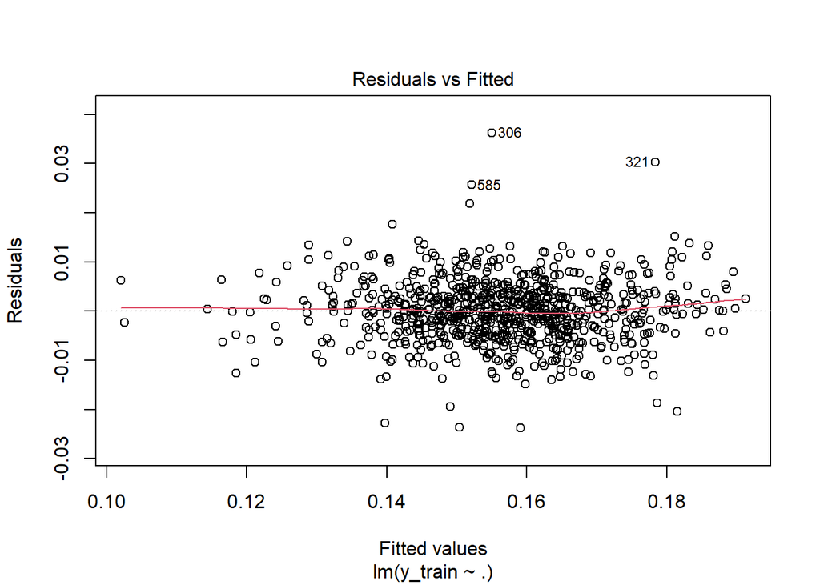

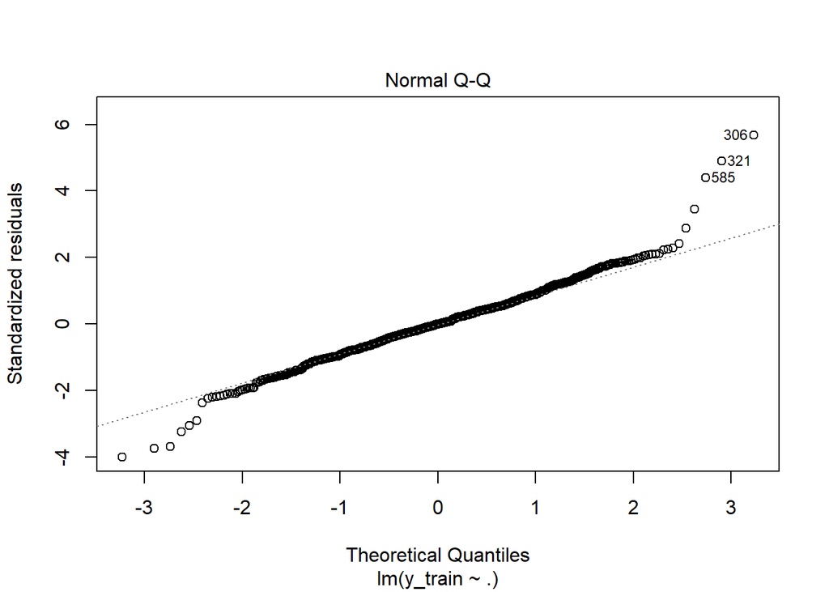

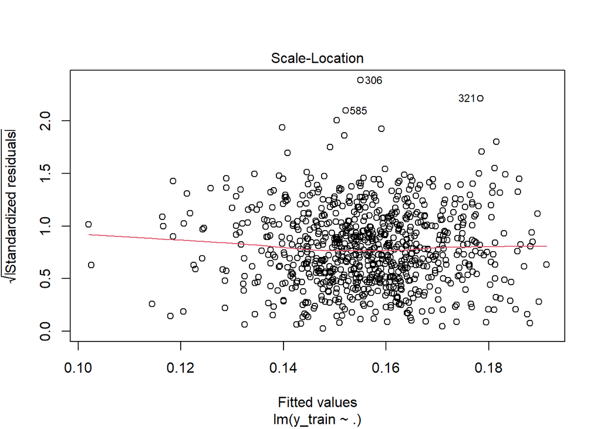

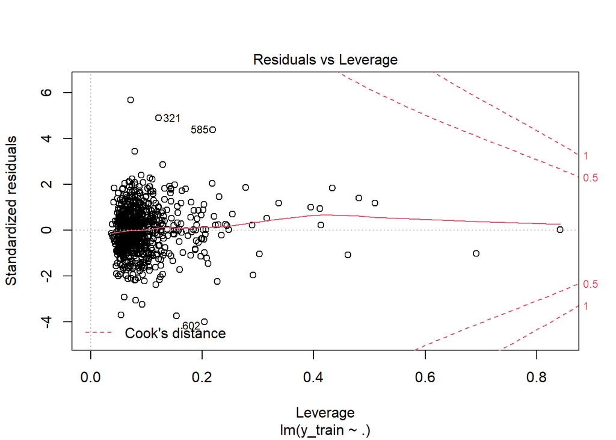

```r
plot(lin_mod)
```

Model with selected features:

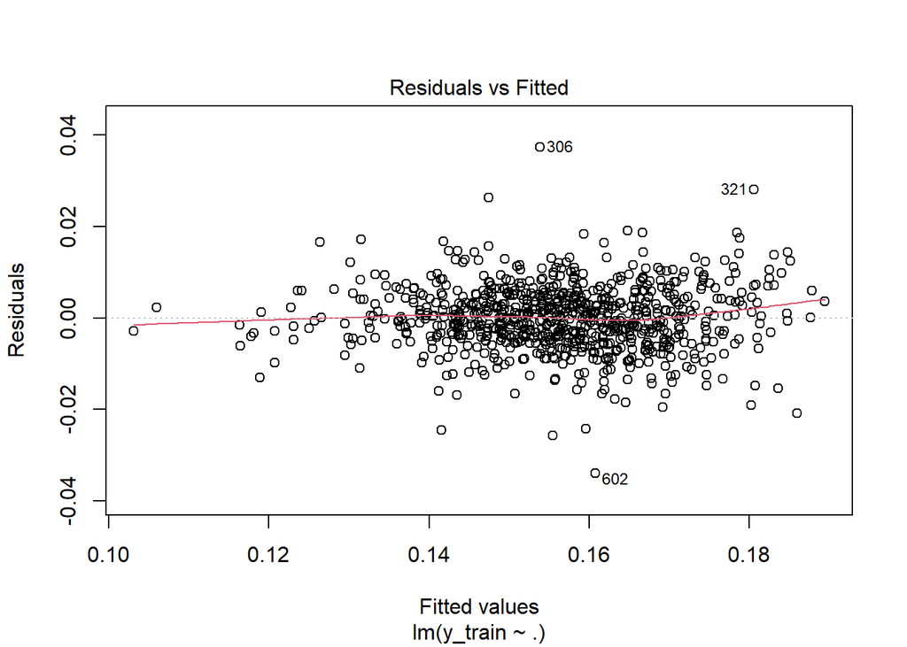

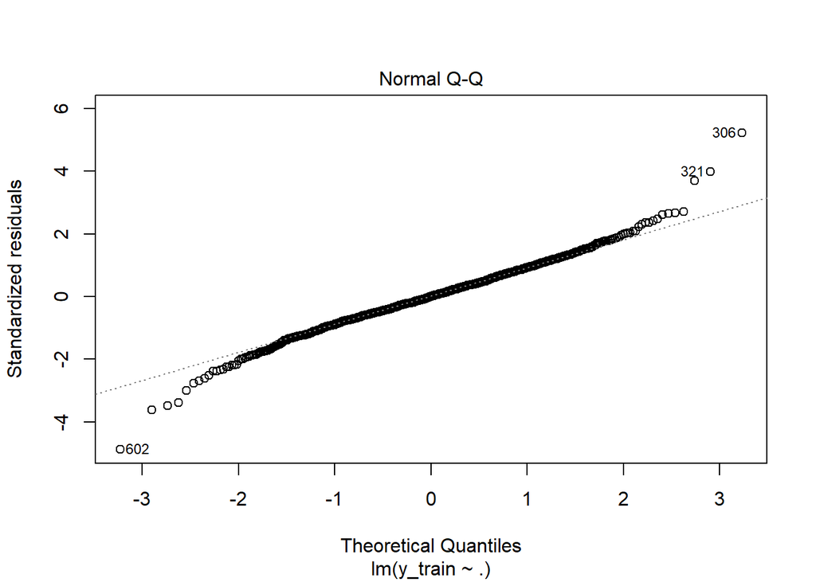

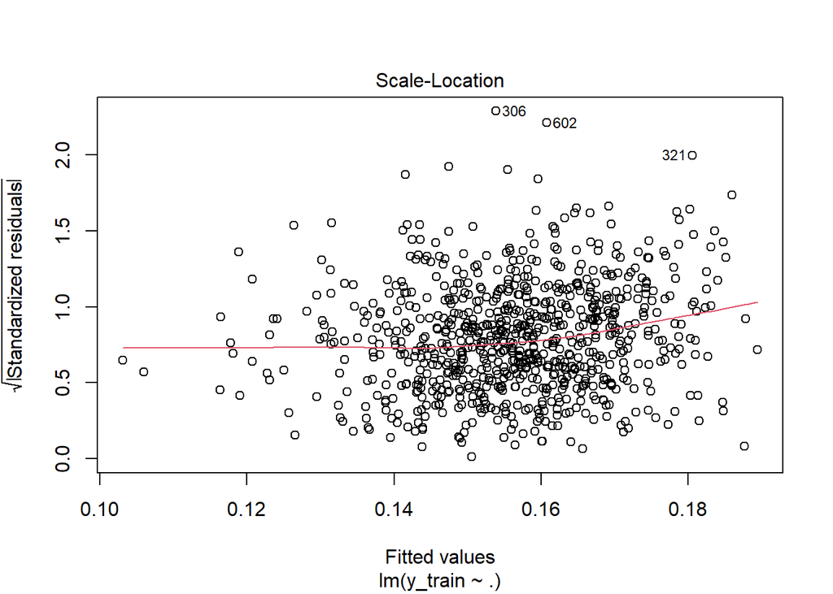

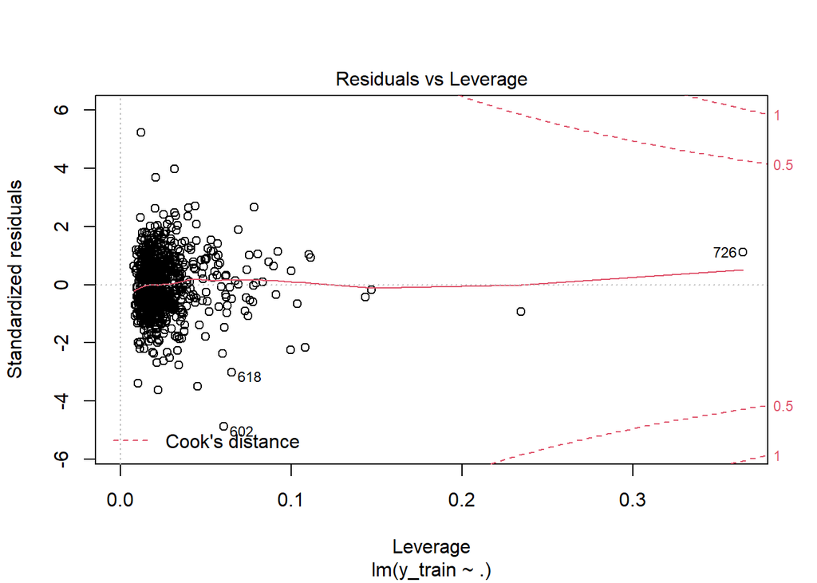

```r
plot(lin_mod_4)
```

Both models are pretty good. The rests are distributed more or less normally, the rest of the graphs are also okay (sort of).

#### Conclusion:

Quite good models were built. The model with selected predictors is slightly inferior in R2 value, but has significant coefficients, which is good for interpretation: for example, the pS6_N and IL1B_N genes are associated with an increase, and BAD_N with a suppression of ERBB4_N expression (according to the constructed model).

### Step 4. PCA

1. Ordination

```r
library(vegan)
study_fit_pca <- rda(scale(df_fill_na[-78]))
```

2. Graphs of factor loadings

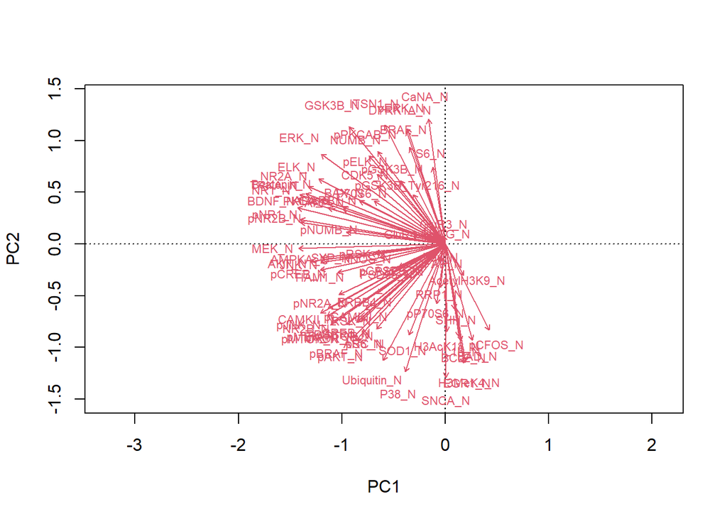

```r
biplot(study_fit_pca, display = 'species', scaling = 'species')
```

It can be seen that there are many multicolinear variables (which was confirmed at the stage of linear regression)

+Screeplot

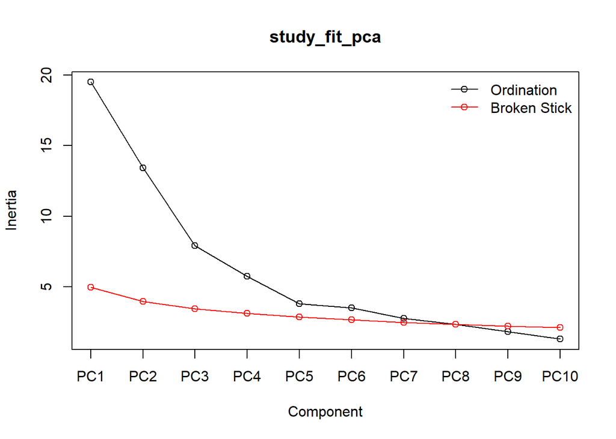

```r
screeplot(study_fit_pca, type = "lines", bstick = TRUE)
```

```r
# On this graph we can see, that 8 components we can consider
```

3. Percent variance for each component

```r
su <- summary(study_fit_pca)
su$cont
```

```
## $importance
## Importance of components:
##                           PC1     PC2    PC3     PC4     PC5     PC6     PC7
## Eigenvalue            19.4965 13.4141 7.9266 5.76579 3.82453 3.53185 2.75704
## Proportion Explained   0.2532  0.1742 0.1029 0.07488 0.04967 0.04587 0.03581
## Cumulative Proportion  0.2532  0.4274 0.5304 0.60524 0.65490 0.70077 0.73658
##                           PC8     PC9    PC10    PC11    PC12    PC13    PC14
## Eigenvalue            2.34716 1.81952 1.31018 1.16805 0.94549 0.86350 0.82578
## Proportion Explained  0.03048 0.02363 0.01702 0.01517 0.01228 0.01121 0.01072
## Cumulative Proportion 0.76706 0.79069 0.80771 0.82288 0.83515 0.84637 0.85709
##                           PC15     PC16     PC17     PC18     PC19     PC20
## Eigenvalue            0.760809 0.677845 0.596688 0.584488 0.484679 0.452347
## Proportion Explained  0.009881 0.008803 0.007749 0.007591 0.006295 0.005875
## Cumulative Proportion 0.866974 0.875777 0.883527 0.891117 0.897412 0.903287
##                           PC21     PC22     PC23     PC24     PC25     PC26
## Eigenvalue            0.430775 0.421417 0.399832 0.370649 0.358646 0.341992
## Proportion Explained  0.005594 0.005473 0.005193 0.004814 0.004658 0.004441
## Cumulative Proportion 0.908881 0.914354 0.919547 0.924360 0.929018 0.933459
##                           PC27     PC28     PC29     PC30    PC31     PC32
## Eigenvalue            0.311475 0.310412 0.263066 0.245394 0.23174 0.219830
## Proportion Explained  0.004045 0.004031 0.003416 0.003187 0.00301 0.002855
## Cumulative Proportion 0.937505 0.941536 0.944952 0.948139 0.95115 0.954004
##                           PC33     PC34     PC35     PC36     PC37     PC38
## Eigenvalue            0.211326 0.200590 0.174475 0.165846 0.160607 0.155296
## Proportion Explained  0.002744 0.002605 0.002266 0.002154 0.002086 0.002017
## Cumulative Proportion 0.956748 0.959353 0.961619 0.963773 0.965859 0.967876
##                          PC39     PC40     PC41    PC42     PC43     PC44
## Eigenvalue            0.15012 0.142811 0.128470 0.12786 0.117245 0.113105
## Proportion Explained  0.00195 0.001855 0.001668 0.00166 0.001523 0.001469
## Cumulative Proportion 0.96983 0.971680 0.973348 0.97501 0.976532 0.978000
##                           PC45     PC46     PC47    PC48     PC49     PC50
## Eigenvalue            0.108354 0.102274 0.099051 0.09392 0.091494 0.087412
## Proportion Explained  0.001407 0.001328 0.001286 0.00122 0.001188 0.001135
## Cumulative Proportion 0.979408 0.980736 0.982022 0.98324 0.984430 0.985566
##                          PC51     PC52      PC53      PC54      PC55      PC56
## Eigenvalue            0.08011 0.077435 0.0742441 0.0707688 0.0660450 0.0601328
## Proportion Explained  0.00104 0.001006 0.0009642 0.0009191 0.0008577 0.0007809
## Cumulative Proportion 0.98661 0.987612 0.9885758 0.9894949 0.9903526 0.9911336
##                            PC57      PC58      PC59     PC60      PC61
## Eigenvalue            0.0568953 0.0536763 0.0523904 0.049899 0.0485275
## Proportion Explained  0.0007389 0.0006971 0.0006804 0.000648 0.0006302
## Cumulative Proportion 0.9918725 0.9925695 0.9932499 0.993898 0.9945282
##                            PC62    PC63      PC64      PC65      PC66      PC67
## Eigenvalue            0.0473655 0.04235 0.0385208 0.0370148 0.0364434 0.0347469
## Proportion Explained  0.0006151 0.00055 0.0005003 0.0004807 0.0004733 0.0004513
## Cumulative Proportion 0.9951433 0.99569 0.9961936 0.9966743 0.9971476 0.9975988
##                            PC68     PC69      PC70      PC71      PC72
## Eigenvalue            0.0309642 0.027646 0.0249932 0.0238962 0.0197832
## Proportion Explained  0.0004021 0.000359 0.0003246 0.0003103 0.0002569
## Cumulative Proportion 0.9980010 0.998360 0.9986846 0.9989949 0.9992519
##                            PC73      PC74      PC75      PC76
## Eigenvalue            0.0163467 0.0153600 0.0148177 0.0110823
## Proportion Explained  0.0002123 0.0001995 0.0001924 0.0001439
## Cumulative Proportion 0.9994642 0.9996636 0.9998561 1.0000000
```

We need 6 components to explain 70% of dispersion

4. 3D plot for the first 3 components

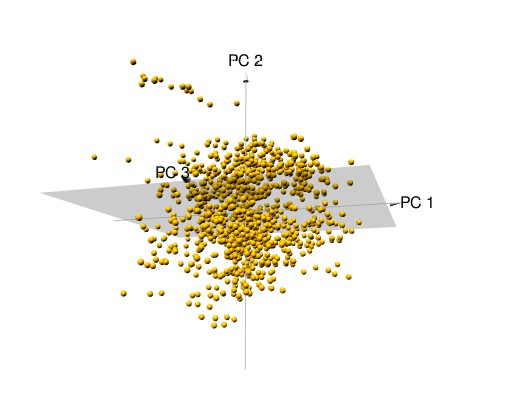

```r
library('pca3d')
pca <- prcomp(scale(df_fill_na[-78]))
# This code create 3D-plot in separate window and we save Fig and load it into RMD
#pca3d(pca)
#snapshotPCA3d(file="first_plot.png")
```

### Step 5. sPLS-DA

Let’s transform the data

```r
library(mixOmics)
library(dplyr)
X <- df_fill_na[-78]
Y <- df_fill_na$class
```

Selection of parameters based on cross-validation:

```r
list.keepX <- c(5:10,  seq(20, 100, 10))
set.seed(30)
# the number of components is taken as the number of groups-1
tune.splsda.srbct <- tune.splsda(X, Y, ncomp = 7,
                                 validation = 'Mfold',
                                 folds = 3, dist = 'max.dist', progressBar = FALSE,
                                 measure = "BER", test.keepX = list.keepX,
                                 nrepeat = 10)
ncomp <- tune.splsda.srbct$choice.ncomp$ncomp
```

We determine which components and with what number of features should be left

```r
select.keepX <- tune.splsda.srbct$choice.keepX[1:ncomp]
select.keepX
```

```
## comp1 comp2 comp3 comp4 comp5 comp6 comp7
##    20     5     5    10     5    70    10
```

Let’s draw a graph. RMD constantly rolled out an error, so I made a separate graph and saved it. Everything works fine in code mode, but Knit doesn’t want to link the document.

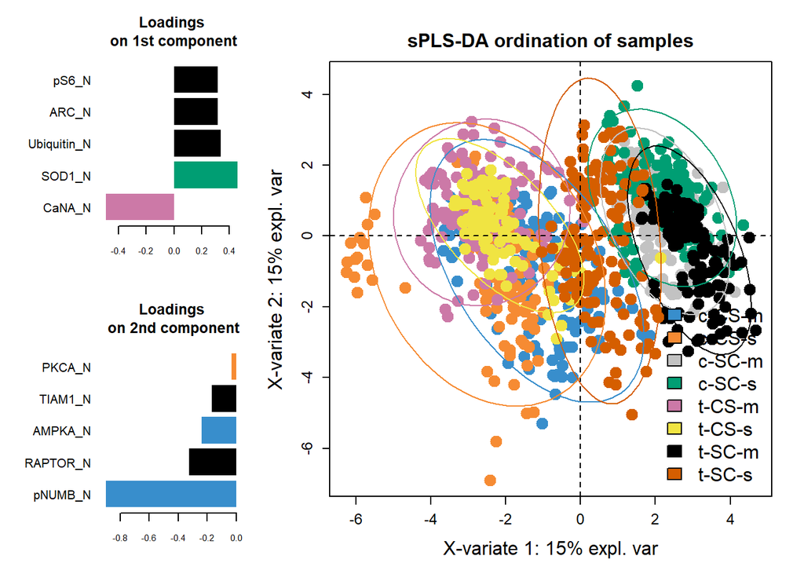

```r
MyResult.splsda.fixed <- splsda(X, Y, ncomp = ncomp, keepX = select.keepX)
#
layout(matrix(c(1, 2, 3, 3, 3, 3), 2, 3))
plotLoadings(MyResult.splsda.fixed, comp = 1, size.name = 1, size.title = 1.2, title = "Loadings\n on 1st component", contrib = "max", legend = F, ndisplay = 5)
#
plotLoadings(MyResult.splsda.fixed, comp = 2, size.name = 1, size.title = 1.2, title = "Loadings\n on 2nd component", contrib = "max",ndisplay = 5,  legend = F)
#
plotIndiv(MyResult.splsda.fixed, ind.names = F, ellipse = T, style = "graphics", abline = TRUE, cex = 2, pch = 19, size.axis = 1.2, size.xlabel = 1.5, size.ylabel = 1.5, title = "sPLS-DA ordination of samples", size.title = 1.5)
legend("bottomright", legend = levels(factor(df_fill_na$class)), cex = 1.5, fill = color.mixo(1:8), bty = "n")
```

#### Let’s make a conclusion. The groups are not well demarcated. According to our ordination:

##### 3) Considering the value of the first component, it can be assumed that CaNA_N and SOD1_N proteins change the most depending on the presence of stimulation.